# Customer Shopping Trend Analysis

Author

Jingwen REN/Dan ZHAO/Yining KONG/Shanwen TANG

Published

March 4, 2024

## Project Recap

With a collection of 3900 records, the **Customer Shopping Preferences Dataset** reveal the purchasing patterns and preferences of our clients, and encompasses a broad spectrum of customer attributes.

we aim to achieve core objectives:

- Data-Driven Product Optimization
- Strategic Marketing Innovations
- Enhancement of Customer Experience

[figure not shown]

### Dataset Glossary

- **Customer ID** - Unique identifier for each customer
- **Age** - Age of the customer
- **Gender** - Gender of the customer (Male/Female)
- **Item Purchased** - The item purchased by the customer
- **Category** - Category of the item purchased
- **Purchase Amount (USD)** - The amount of the purchase in USD
- **Location** - Location where the purchase was made
- **Size** - Size of the purchased item
- **Color** - Color of the purchased item
- **Season** - Season during which the purchase was made Review
- **Rating** - Rating given by the customer for the purchased item
- **Subscription Status** - Indicates if the customer has a subscription (Yes/No)
- **Shipping Type** - Type of shipping chosen by the customer
- **Discount Applied** - Indicates if a discount was applied to the purchase (Yes/No)
- **Promo Code Used** - Indicates if a promo code was used for the purchase (Yes/No)
- **Previous Purchases** - The total count of transactions concluded by the customer at the store, excluding the ongoing transaction
- **Payment Method** - Customer’s most preferred payment method
- **Frequency of Purchases** - Frequency at which the customer makes purchases (e.g., Weekly, Fortnightly, Monthly)

### Analytics Team

We are the Analytics Team in **JD_KT** Audit Company:

**Jingwen REN**

**Dan ZHAO**

**Yining KONG**

**Shanwen TANG**

[figure not shown]

## Data preparation

### Packages Prepare

```r
library(tidyverse)
library(knitr)
library(gt)
library(readxl)
library(readr)
library(ggplot2)
library(dataMaid)
library(RSQLite)
library(tidytext)
library(dplyr)
library(gridExtra)
library(lubridate)
library(janitor)
library(ggthemes)
```

### Glimpse the data

**shopping_trends_updated.csv**

Feature: Number of observations( 3900 ) Number of variables( 18 )

```r
shopping_trends_2 <- read_csv("shopping_trends_updated.csv")
```

**shopping_trends.csv**

Feature: Number of observations( 3900 ) Number of variables( 19 )

## Data Cleaning

```r
## Clean the col names
shopping_trends_1 <-shopping_trends_1 %>%
  clean_names()%>%
  setNames(tools::toTitleCase(names(.)))

shopping_trends_2 <-shopping_trends_2 %>%
  clean_names()%>%
  setNames(tools::toTitleCase(names(.)))

## Check the results
shopping_trends_1 %>%
  head(1)
```

```
# A tibble: 1 × 19
  Customer_id   Age Gender Item_purchased Category Purchase_amount_usd Location
        <dbl> <dbl> <chr>  <chr>          <chr>                  <dbl> <chr>
1           1    55 Male   Blouse         Clothing                  53 Kentucky
# ℹ 12 more variables: Size <chr>, Color <chr>, Season <chr>,
#   Review_rating <dbl>, Subscription_status <chr>, Payment_method <chr>,
#   Shipping_type <chr>, Discount_applied <chr>, Promo_code_used <chr>,
#   Previous_purchases <dbl>, Preferred_payment_method <chr>,
#   Frequency_of_purchases <chr>
```

```r
shopping_trends_2%>%
  head(1)
```

```
# A tibble: 1 × 18
  Customer_id   Age Gender Item_purchased Category Purchase_amount_usd Location
        <dbl> <dbl> <chr>  <chr>          <chr>                  <dbl> <chr>
1           1    55 Male   Blouse         Clothing                  53 Kentucky
# ℹ 11 more variables: Size <chr>, Color <chr>, Season <chr>,
#   Review_rating <dbl>, Subscription_status <chr>, Shipping_type <chr>,
#   Discount_applied <chr>, Promo_code_used <chr>, Previous_purchases <dbl>,
#   Payment_method <chr>, Frequency_of_purchases <chr>
```

Then we use SQLite function to join two tables.

```r
## Use SQLite function to join two tables
con <- dbConnect(RSQLite::SQLite(), dbname = "your_database.db")
dbWriteTable(con, "shopping_trends_2_table", shopping_trends_2,overwrite = TRUE)
dbWriteTable(con, "shopping_trends_1_table", shopping_trends_1,overwrite = TRUE)

query <- "
SELECT
  shopping_trends_2_table.*,
  shopping_trends_1_table.Preferred_payment_method
FROM
  shopping_trends_2_table
LEFT JOIN
  shopping_trends_1_table
ON
  shopping_trends_2_table.Customer_id = shopping_trends_1_table.Customer_id
"
result1 <- dbGetQuery(con, query)

apply(result1, 2, max, na.rm = TRUE)
```

```
             Customer_id                      Age                   Gender
                  "3900"                     "70"                   "Male"
          Item_purchased                 Category      Purchase_amount_usd
               "T-shirt"              "Outerwear"                    "100"
                Location                     Size                    Color
               "Wyoming"                     "XL"                 "Yellow"
                  Season            Review_rating      Subscription_status
                "Winter"                    "5.0"                    "Yes"
           Shipping_type         Discount_applied          Promo_code_used
          "Store Pickup"                    "Yes"                    "Yes"
      Previous_purchases           Payment_method   Frequency_of_purchases
                    "50"                  "Venmo"                 "Weekly"
Preferred_payment_method
                 "Venmo"
```

## Data Summary

```r
shopping_trends <- as.data.frame(result1)

summary(shopping_trends)
```

```
  Customer_id          Age           Gender          Item_purchased
 Min.   :   1.0   Min.   :18.00   Length:3900        Length:3900
 1st Qu.: 975.8   1st Qu.:31.00   Class :character   Class :character
 Median :1950.5   Median :44.00   Mode  :character   Mode  :character
 Mean   :1950.5   Mean   :44.07
 3rd Qu.:2925.2   3rd Qu.:57.00
 Max.   :3900.0   Max.   :70.00
   Category         Purchase_amount_usd   Location             Size
 Length:3900        Min.   : 20.00      Length:3900        Length:3900
 Class :character   1st Qu.: 39.00      Class :character   Class :character
 Mode  :character   Median : 60.00      Mode  :character   Mode  :character
                    Mean   : 59.76
                    3rd Qu.: 81.00
                    Max.   :100.00
    Color              Season          Review_rating  Subscription_status
 Length:3900        Length:3900        Min.   :2.50   Length:3900
 Class :character   Class :character   1st Qu.:3.10   Class :character
 Mode  :character   Mode  :character   Median :3.70   Mode  :character
                                       Mean   :3.75
                                       3rd Qu.:4.40
                                       Max.   :5.00
 Shipping_type      Discount_applied   Promo_code_used    Previous_purchases
 Length:3900        Length:3900        Length:3900        Min.   : 1.00
 Class :character   Class :character   Class :character   1st Qu.:13.00
 Mode  :character   Mode  :character   Mode  :character   Median :25.00
                                                          Mean   :25.35
                                                          3rd Qu.:38.00
                                                          Max.   :50.00
 Payment_method     Frequency_of_purchases Preferred_payment_method
 Length:3900        Length:3900            Length:3900
 Class :character   Class :character       Class :character
 Mode  :character   Mode  :character       Mode  :character
```

## Data Analysis

### Analysis 1

Group customers according to **age** and the proportion of **male and female** in each group.

```r
Age_group <- function(age) {
  if (age >= 18 & age <= 35) {
    return("Youth")
  } else if (age > 35 & age <= 60) {
    return("Middle_age")
  } else {
    return("Elderly")
  }
}


df <- data.frame(Age = shopping_trends$Age, Gender = shopping_trends$Gender)
df$Age_group <- sapply(df$Age, Age_group)
summary_df <- df %>%
  dplyr::group_by(Age_group, Gender) %>%
  dplyr::summarize(count = n(), .groups = "drop") %>%
  dplyr::group_by(Age_group) %>%
  dplyr::mutate(total_count = sum(count),
         percentage = paste0(round(count / total_count * 100, 2), "%")) %>%
  dplyr::ungroup() %>%
  dplyr::arrange(Age_group, desc(Gender)) %>%
  dplyr::select(-total_count)
```

```r
summary_df %>%
  gt()
```

| Age_group | Gender | count | percentage |
| --- | --- | --- | --- |
| Elderly | Male | 495 | 68.46% |
| Elderly | Female | 228 | 31.54% |
| Middle_age | Male | 1259 | 67.54% |
| Middle_age | Female | 605 | 32.46% |
| Youth | Male | 898 | 68.39% |
| Youth | Female | 415 | 31.61% |

**Result**

The **Middle age** Group (35-60) has the larest number (including male and female).

The proportion of **male** is larger than **female** in all groups.

### Analysis 2

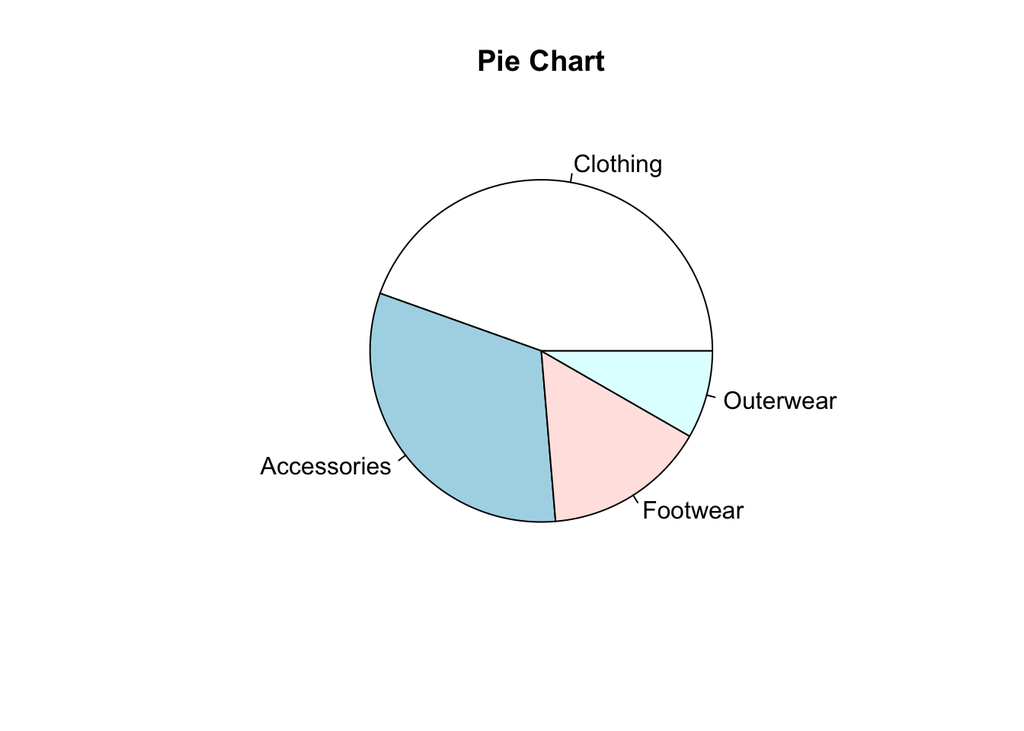

```r
# 2.1The most popular category
 Category_group <- shopping_trends %>%
  group_by(Category) %>%
  summarise(count = n()) %>%
  arrange(desc(count))
pie(Category_group$count,
    labels = Category_group$Category, main = "Pie Chart")
```

**Result**

The most popular category is Clothing.

```r
# 2.2 The three largest items proportion in Clothing
 items_category <- dplyr:::select(shopping_trends,Item_purchased, Category)
 items_category_1 <-items_category %>%
   dplyr:::filter(Category == "Clothing")%>%
   group_by(Item_purchased)%>%
   summarise(count = n())%>%
   slice_max(order_by=Item_purchased,
            n=3)
items_category_1 %>%
  gt()
```

| Item_purchased | count |
| --- | --- |
| T-shirt | 147 |
| Sweater | 164 |
| Socks | 159 |

### Analysis 3

The **Season** correlate with the **purchase amount**.

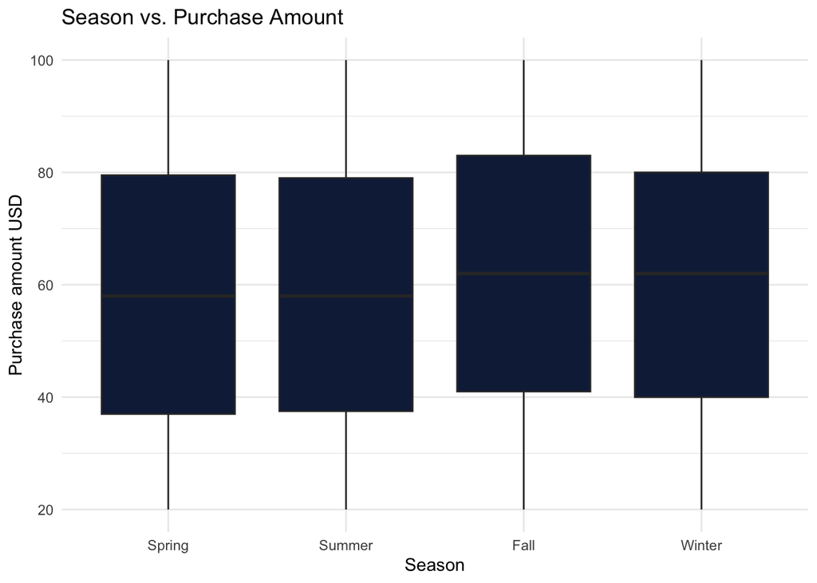

```r
shopping_trends$Season <- factor(shopping_trends$Season, levels = c("Spring", "Summer", "Fall", "Winter"))
ggplot(shopping_trends) +
 aes(x = Season, y = Purchase_amount_usd) +
 geom_boxplot(fill = "#112446") +
 labs(x = "Season", y = "Purchase amount USD", title = "Season vs. Purchase Amount ") +
theme(axis.text.x = element_text(size = 15))+
 theme_minimal()
```

**Result**

The season of Fall is the highest in Purchase amount.

### Analysis 4

The most common shipping type for customers with a review rating above 4.

```r
common_type <- shopping_trends %>%
  filter(Review_rating > 4) %>%
  group_by(Shipping_type) %>%
  summarise(n = n()) %>%
  arrange(desc(n)) %>%
  slice(1)
common_type %>%
  gt()
```

| Shipping_type | n |
| --- | --- |
| Standard | 272 |

**Result**

The most common shipping type for customers with a review rating above 4 is **Standard**.

### Analysis 5

Best Color sold in each Season.

```r
season_color_sales <- shopping_trends %>%
  group_by(Season, Color) %>%
  summarise(Count = n())
top_colors <- season_color_sales %>%
  group_by(Season) %>%
  top_n(1, Count)
top_colors <- top_colors[match(c("Spring", "Summer", "Fall", "Winter"),
                               top_colors$Season), ]
top_colors %>%
  ungroup() %>%
  gt()
```

| Season | Color | Count |
| --- | --- | --- |
| Spring | Olive | 52 |
| Summer | Silver | 59 |
| Fall | Magenta | 50 |
| Winter | Green | 50 |

**Suggestion**

Optimise inventory management and supply chain strategies according to seasonal changes and color popularity. Design seasonal promotions and discount campaigns accordingly.

### Analysis 6

The average purchase amount for customers who have made more than 30 previous purchases.

```r
avg_purchase <- mean(
  shopping_trends$Purchase_amount_usd[
    shopping_trends$Previous_purchases > 30
    ],
  na.rm = TRUE
  ) %>%
  round(digits = 2)
print(avg_purchase)
```

```
[1] 60.03
```

**Result**

The average purchase amount is **60.03**.

### Analysis 7

The average purchase amount for customers who have a **subscription** and used **Venmo** as the payment method.

```r
# Filter for customers with a subscription and who used Venmo
filtered_data <- shopping_trends %>%
  filter(Subscription_status == "Yes", Payment_method == "Venmo")

# Calculate the average purchase amount
average_purchase_amount <- filtered_data %>%
  summarise(AverageAmount = mean(Purchase_amount_usd))

#print(average_purchase_amount)
```

### Analysis 8

Locations with stronger purchase power and more subscribed members.

```r
## Filter the subscribed members
subscribed_members <- shopping_trends %>%
  filter(Subscription_status == "Yes")

## TOP6 Locations with stronger purchase power
top6_purchase_power <- subscribed_members %>%
  group_by(Location) %>%
  summarise(Total_Purchase_Amount = sum(Purchase_amount_usd)) %>%
  top_n(6, Total_Purchase_Amount)



## TOP6 Locations with most Subscription members
top6_members_count <- subscribed_members %>%
  group_by(Location) %>%
  summarise(Members_Count = n_distinct(Customer_id)) %>%
  top_n(6, Members_Count)



## bar charts
top_purchases_plot <-
  ggplot(top6_purchase_power,
         aes(x = reorder(Location, -Total_Purchase_Amount),
             y = Total_Purchase_Amount, fill = Location)) +
  geom_bar(stat = "identity") +
  geom_text(aes(label = sprintf("%.2f", Total_Purchase_Amount)),
            stat = "identity",
            position = position_stack(vjust = 0.5),
            colour = "white", size = 2) +
  scale_fill_brewer(palette = "Set2", direction = 1) +
  ggthemes::theme_fivethirtyeight() +
  theme(text = element_text(size = 9),
        plot.title = element_text(size = 9),
        axis.text.x = element_text(angle = 45, hjust = 1),
        legend.key.size = unit(0.3, "cm"),
        legend.title = element_blank()) +
  labs(title = "Top 6 Locations by Total Purchase(USD)", x = "Location", y = "Total Purchase Amount (USD)")

top_members_plot <-
  ggplot(top6_members_count,
         aes(x = reorder(Location, -Members_Count),
             y = Members_Count, fill = Location)) +
  geom_bar(stat = "identity") +
  geom_text(aes(label = sprintf("%0.0f", Members_Count)),
            stat = "identity",
            position = position_stack(vjust = 0.5),
            colour = "white", size = 2) +
  scale_fill_brewer(palette = "Set2", direction = 1) +
  ggthemes::theme_fivethirtyeight() +
  theme(text = element_text(size = 9),
        plot.title = element_text(size = 9),
        axis.text.x = element_text(angle = 45, hjust = 1),
        legend.key.size = unit(0.3, "cm"),
        legend.title = element_blank()) +
  labs(title = "Top 6 Locations by Members", x = "Location", y = "Members Count")
```

**Finding**

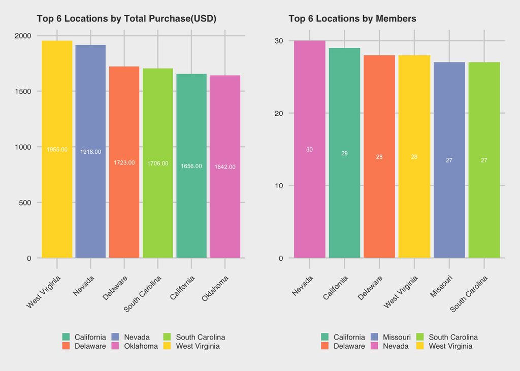

```r
grid.arrange(top_purchases_plot, top_members_plot, ncol = 2)
```

### Recommendations

[figure not shown]

[figure not shown]

##### For Missouri:

- **Increase exclusive member discounts**: To enhance purchasing power, offer exclusive discounts and double points accumulation for members, encouraging consumption.
- **Enhance user engagement**: By hosting exclusive events for members, increase their sense of participation and brand loyalty, thereby enhancing their willingness to purchase.

##### For Oklahoma:

- **Referral reward program**: Implement a referral reward program to encourage existing members to refer new users to register as members, attracting more users through word-of-mouth.
- **Coupons and trials**: Provide coupons or free trials for new registered users to lower their initial purchase threshold.

## Strategic proposals

[figure not shown]

## Project Division

Here is our work division among four group members

[figure not shown]

- **REN Jingwen**: Intro + Data Cleaning
- **ZHAO Dan**: Q1 + Q2 + Q3
- **KONG Yining**: Q4 + Q5 + Q6
- **TANG Shanwen**: Q7 + Q8 + Recommendation

## References

- https://www.kaggle.com/datasets/iamsouravbanerjee/customer-shopping-trends-dataset/data
- https://quarto.org/docs/presentations/revealjs/
- https://bookdown.org/yihui/rmarkdown/markdown-syntax.html